# Process mining_simplified

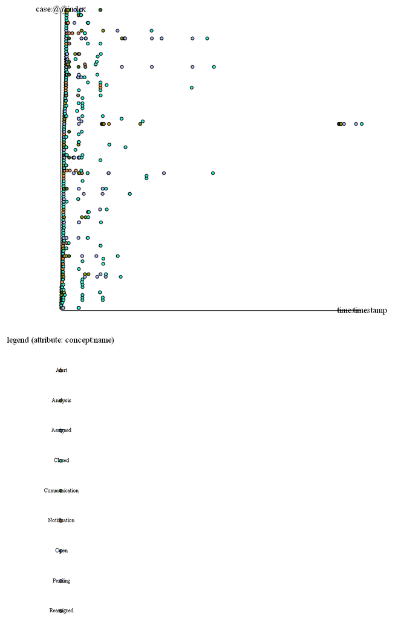

```python
# Overview of logs using dotted chart

# The dotted chart is a classic visualization of the events inside an event log across different dimensions
# Each event of the event log is corresponding to a point. The dimensions are projected on a graph having:

# X axis: the values of the first dimension are represented there.
# Y-axis: the values of the second dimension are represented there.
# Color: the values of the third dimension are represented as different colors for the points of the dotted chart.

# The dotted chart can be built on different attributes.
# A convenient choice for the dotted chart is to visualize the distribution of cases and events over the time, with the following choices:

# X-axis: the timestamp of the event.
# Y-axis: the index of the case inside the event log.
# Color: the activity of the event.

pm4py.view_dotted_chart(log, format="png")
```

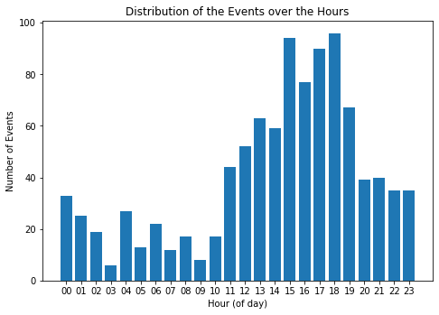

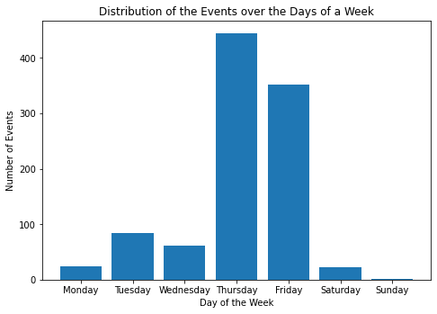

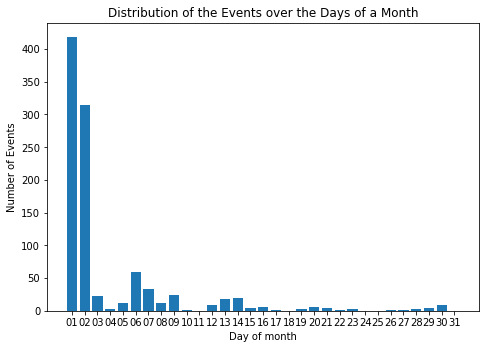

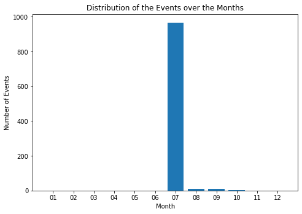

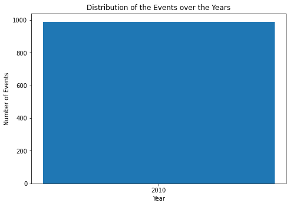

```python
# Distribution of events agains different time scales
pm4py.view_events_distribution_graph(log, distr_type="hours", format="png")
pm4py.view_events_distribution_graph(log, distr_type="days_week", format="png")
pm4py.view_events_distribution_graph(log, distr_type="days_month", format="png")
pm4py.view_events_distribution_graph(log, distr_type="months", format="png")
pm4py.view_events_distribution_graph(log, distr_type="years", format="png")
```

Performing batch analysis

We say that an activity is executed in batches by a given resource when the resource executes several times the same activity in a short period of time.

Identifying such activities may identify points of the process that can be automated, since the activity of the person may be repetitive

There are indeed different types of batches that are detected by our method:

- Simultaneous: all the events in the batch have identical start and end timestamps. Batching at start: all the events in the batch have identical start timestamp. Batching at end: all the events in the batch have identical end timestamp. Sequential batching: for all the consecutive events, the end of the first is equal to the start of the second. Concurrent batching: for all the consecutive events that are not sequentially matched.

```python
# Investigate batches
from pm4py.algo.discovery.batches import algorithm
batches = algorithm.apply(log)

for act_res in batches:
    print("")
    print("activity: "+act_res[0][0]+" resource: "+act_res[0][1])
    print("number of distinct batches: "+str(act_res[1]))
    for batch_type in act_res[2]:
        print(batch_type, len(act_res[2][batch_type]))
```

```
activity: Alert resource: RES81
number of distinct batches: 14
Concurrent batching 14

activity: Pending resource: RES841
number of distinct batches: 4
Concurrent batching 4

activity: Notification resource: RES471
number of distinct batches: 3
Concurrent batching 3

activity: Analysis resource: RES471
number of distinct batches: 3
Concurrent batching 3

activity: Pending resource: RES361
number of distinct batches: 2
Concurrent batching 2

activity: Notification resource: RES431
number of distinct batches: 2
Simultaneous 2

activity: Notification resource: RES221
number of distinct batches: 2
Concurrent batching 2

activity: Closed resource: RES71
number of distinct batches: 2
Concurrent batching 2

activity: Closed resource: RES561
number of distinct batches: 2
Concurrent batching 2

activity: Analysis resource: RES711
number of distinct batches: 2
Concurrent batching 2

```

[output cut: 220 more lines]

```
activity: Analysis resource: RES121
number of distinct batches: 1
Concurrent batching 1

activity: Analysis resource: RES1201
number of distinct batches: 1
Concurrent batching 1

activity: Analysis resource: RES11
number of distinct batches: 1
Concurrent batching 1

activity: Analysis resource: RES101
number of distinct batches: 1
Concurrent batching 1
```

```python
batches
```

[output not shown]

[output cut: 519 more lines]

[output not shown]

The rework statistic permits to identify the activities which have been repeated during the same process execution. This shows the underlying inefficiencies in the process.

In our implementation, the rework takes into account an event log / Pandas dataframe and returns a dictionary associating to each activity the number of cases containing the rework for the given activity.

```python
# Investigate rework at activity level
rework = pm4py.get_rework_cases_per_activity(log)
rework
```

```
{'Notification': 23,
 'Assigned': 19,
 'Analysis': 45,
 'Reassigned': 26,
 'Alert': 34,
 'Closed': 30,
 'Pending': 21,
 'Communication': 6}
```

For example, if a case contains the following activities: A,B,A,B,C,D; the rework is 2 since the events in position 3 and 4 are referring to activities that have already been included previously.

The rework statistic can be useful to identify the cases in which many events are repetitions of activities that have already been performed

```python
# Investigate rework at case level
dictio = pm4py.get_rework_cases_per_activity(log)
dictio
```

```
{'Notification': 23,
 'Assigned': 19,
 'Analysis': 45,
 'Reassigned': 26,
 'Alert': 34,
 'Closed': 30,
 'Pending': 21,
 'Communication': 6}
```

```python
from pm4py.algo.transformation.log_to_interval_tree import algorithm as log_to_interval_tree
it = log_to_interval_tree.apply(log)

# To compute the workload (number of events) for every resource in the specified interval

from collections import Counter
intersecting_events = it[1093836400:1323644400]
open_paths = Counter((x.data["source_event"]["concept:name"], x.data["target_event"]["concept:name"]) for x in intersecting_events)
open_paths
```

```
Counter({('Analysis', 'Assigned'): 24,
         ('Pending', 'Reassigned'): 3,
         ('Pending', 'Pending'): 29,
         ('Analysis', 'Analysis'): 28,
         ('Closed', 'Closed'): 35,
         ('Reassigned', 'Closed'): 27,
         ('Open', 'Notification'): 49,
         ('Alert', 'Alert'): 68,
         ('Notification', 'Closed'): 22,
         ('Reassigned', 'Alert'): 12,
         ('Notification', 'Pending'): 7,
         ('Alert', 'Notification'): 38,
         ('Pending', 'Communication'): 8,
         ('Analysis', 'Reassigned'): 27,
         ('Analysis', 'Closed'): 31,
         ('Analysis', 'Pending'): 28,
         ('Notification', 'Analysis'): 66,
         ('Assigned', 'Notification'): 30,
         ('Assigned', 'Analysis'): 36,
         ('Open', 'Assigned'): 19,
         ('Pending', 'Closed'): 29,
         ('Closed', 'Reassigned'): 2,
         ('Notification', 'Assigned'): 29,
         ('Open', 'Alert'): 42,
         ('Reassigned', 'Pending'): 8,
         ('Reassigned', 'Communication'): 1,
         ('Alert', 'Closed'): 4,
         ('Analysis', 'Communication'): 4,
         ('Notification', 'Reassigned'): 4,
         ('Communication', 'Communication'): 5,
         ('Reassigned', 'Notification'): 10,
         ('Assigned', 'Pending'): 7,
         ('Reassigned', 'Reassigned'): 28,
         ('Reassigned', 'Assigned'): 5,
         ('Pending', 'Assigned'): 6,
         ('Alert', 'Assigned'): 14,
         ('Communication', 'Analysis'): 1,
         ('Pending', 'Analysis'): 13,
         ('Analysis', 'Alert'): 1,
         ('Communication', 'Reassigned'): 1,
         ('Assigned', 'Reassigned'): 25,
         ('Pending', 'Alert'): 2,
         ('Notification', 'Notification'): 6,
         ('Notification', 'Communication'): 5,
         ('Analysis', 'Notification'): 4,
         ('Communication', 'Pending'): 11,
         ('Reassigned', 'Analysis'): 1,
         ('Communication', 'Closed'): 2,
         ('Communication', 'Assigned'): 1,
         ('Communication', 'Notification'): 2,
         ('Open', 'Communication'): 1,
         ('Open', 'Closed'): 3,
         ('Pending', 'Notification'): 1,
         ('Communication', 'Alert'): 1,
         ('Alert', 'Analysis'): 1,
         ('Open', 'Analysis'): 1,
         ('Closed', 'Assigned'): 1,
         ('Open', 'Reassigned'): 1,
         ('Alert', 'Reassigned'): 1,
         ('Assigned', 'Communication'): 1,
         ('Alert', 'Pending'): 1,
         ('Notification', 'Alert'): 1})
```

Some viz

```python
# Let's diplay process model
process_tree = pm4py.discover_process_tree_inductive(log)
pm4py.view_process_tree(process_tree)
```

[output not shown]

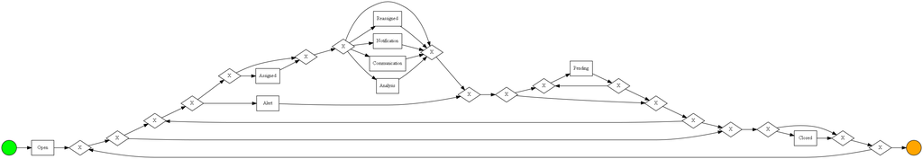

```python
# Let's view process model
bpmn_model = pm4py.convert_to_bpmn(process_tree)
pm4py.view_bpmn(bpmn_model)
```

The graph above shows the BPMN model discovered based on event data set, using the Inductive Miner implementation of PM4Py

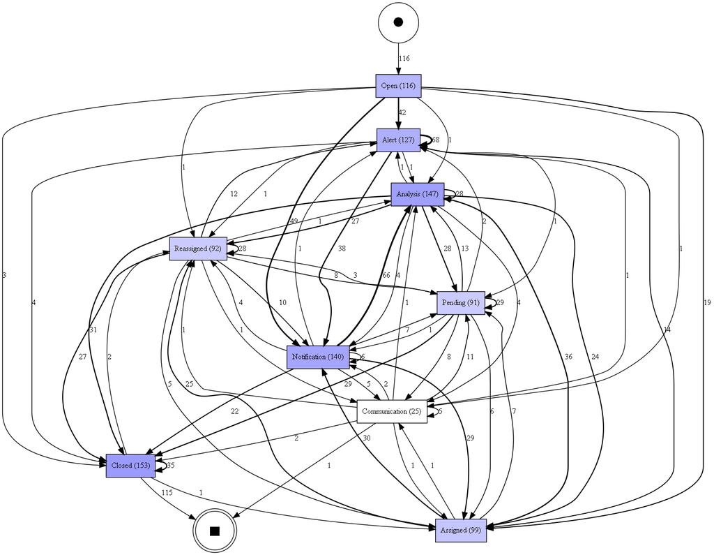

```python
# Let's display Process Map
dfg, start_activities, end_activities = pm4py.discover_dfg(log)
pm4py.view_dfg(dfg, start_activities, end_activities)
```

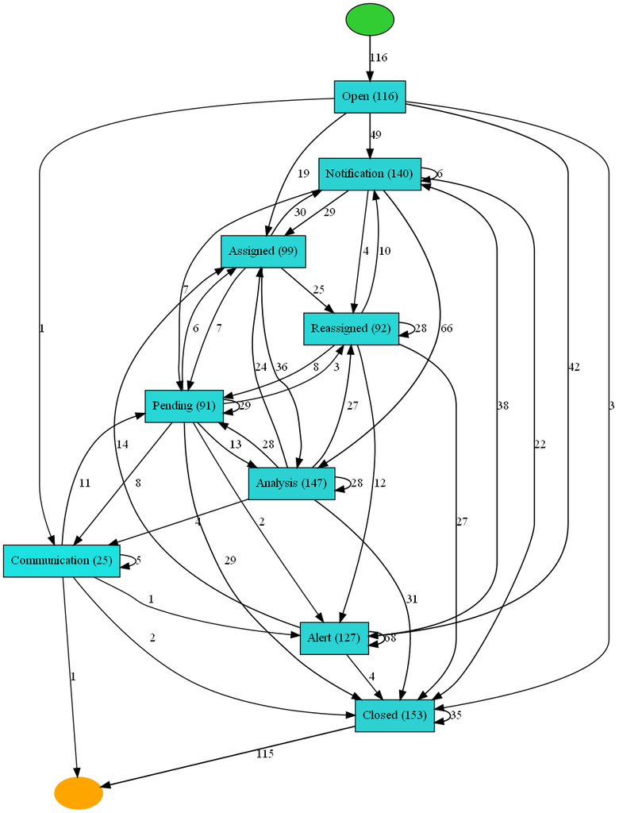

```python
# We can also use another method to have a simpler representation
# Using Heuristic-Miner based process map, the arcs between activities represent observed concurrency.
#Hence, these activities will not be connected in the process map.
#As such, a HM-based process map is typically simpler compared to a DFG-based process map.
map = pm4py.discover_heuristics_net(log)
pm4py.view_heuristics_net(map)
```

### Process discovery algorithms (Alpha, Alpha+,Heuristic,Inductive)

##### ALPHAMINER

The alpha miner is one of the most known Process Discovery algorithm and is able to find:

- A Petri net model where all the transitions are visible and unique and correspond to classified events (for example, to activities).
- An initial marking that describes the status of the Petri net model when a execution starts.
- A final marking that describes the status of the Petri net model when a execution ends.

##### INDUCTIVE MINER

The basic idea of Inductive Miner is about detecting a 'cut' in the log (e.g. sequential cut, parallel cut, concurrent cut and loop cut) and then recur on sublogs, which were found applying the cut, until a base case is found. The Directly-Follows variant avoids the recursion on the sublogs but uses the Directly Follows graph.

Inductive miner models usually make extensive use of hidden transitions, especially for skipping/looping on a portion on the model. Furthermore, each visible transition has a unique label (there are no transitions in the model that share the same label)

##### HEURISTIC MINER

Heuristics Miner is an algorithm that acts on the Directly-Follows Graph, providing way to handle with noise and to find common constructs (dependency between two activities, AND). The output of the Heuristics Miner is an Heuristics Net, so an object that contains the activities and the relationships between them. The Heuristics Net can be then converted into a Petri net

##### DIRECTLY-FOLLOWS GRAPH

Process models modeled using Petri nets have a well-defined semantic: a process execution starts from the places included in the initial marking and finishes at the places included in the final marking. In this section, another class of process models, Directly-Follows Graphs, are introduced. Directly-Follows graphs are graphs where the nodes represent the events/activities in the log and directed edges are present between nodes if there is at least a trace in the log where the source event/activity is followed by the target event/activity. On top of these directed edges, it is easy to represent metrics like frequency (counting the number of times the source event/activity is followed by the target event/activity) and performance (some aggregation, for example, the mean, of time inter-lapsed between the two events/activities).

```python
# Apply alphaminer algorithm
from pm4py.algo.discovery.alpha import algorithm as alpha_miner
net, initial_marking, final_marking = pm4py.discover_petri_net_alpha(log)
```

```python
# Displaying results
from pm4py.visualization.petri_net import visualizer as pn_visualizer
parameters = {pn_visualizer.Variants.FREQUENCY.value.Parameters.FORMAT: "png"}
gviz = pn_visualizer.apply(net, initial_marking, final_marking,
                           parameters=parameters,
                           variant=pn_visualizer.Variants.FREQUENCY,
                           log=log)
pn_visualizer.save(gviz, "aplhaminer2.png")
```

```
replaying log with TBR, completed variants ::   0%|          | 0/92 [00:00<?, ?it/s]
```

```python
# Apply Inductive miner algorithm
net, initial_marking, final_marking = pm4py.discover_petri_net_inductive(log)
tree = pm4py.discover_process_tree_inductive(log)
pm4py.view_process_tree(tree)
```

[output not shown]

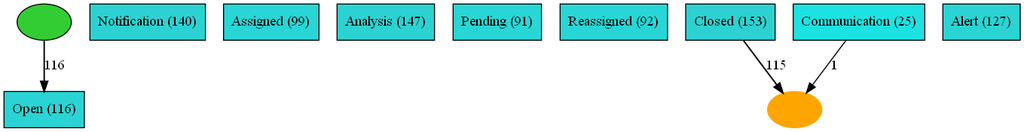

```python
# Apply Heuristic miner algorithm
heu_net = pm4py.discover_heuristics_net(log, dependency_threshold=0.99)
pm4py.view_heuristics_net(heu_net)
```

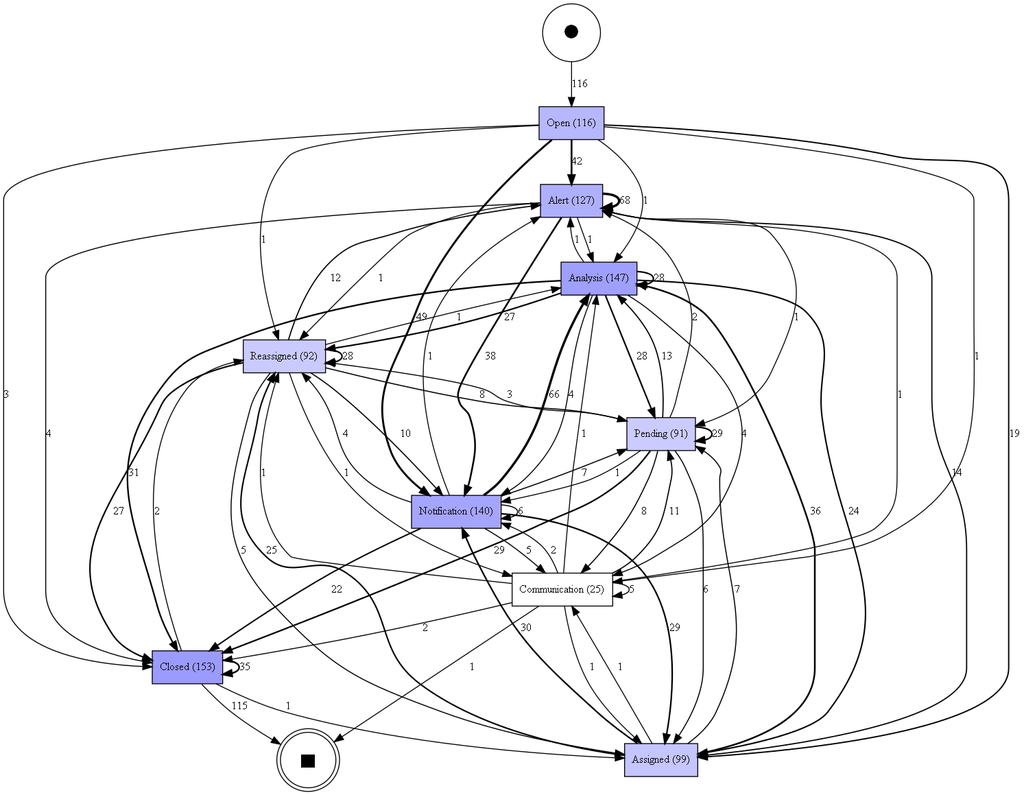

```python
# Apply Direcly follows graph
dfg, start_activities, end_activities = pm4py.discover_dfg(log)
pm4py.view_dfg(dfg, start_activities, end_activities)
```

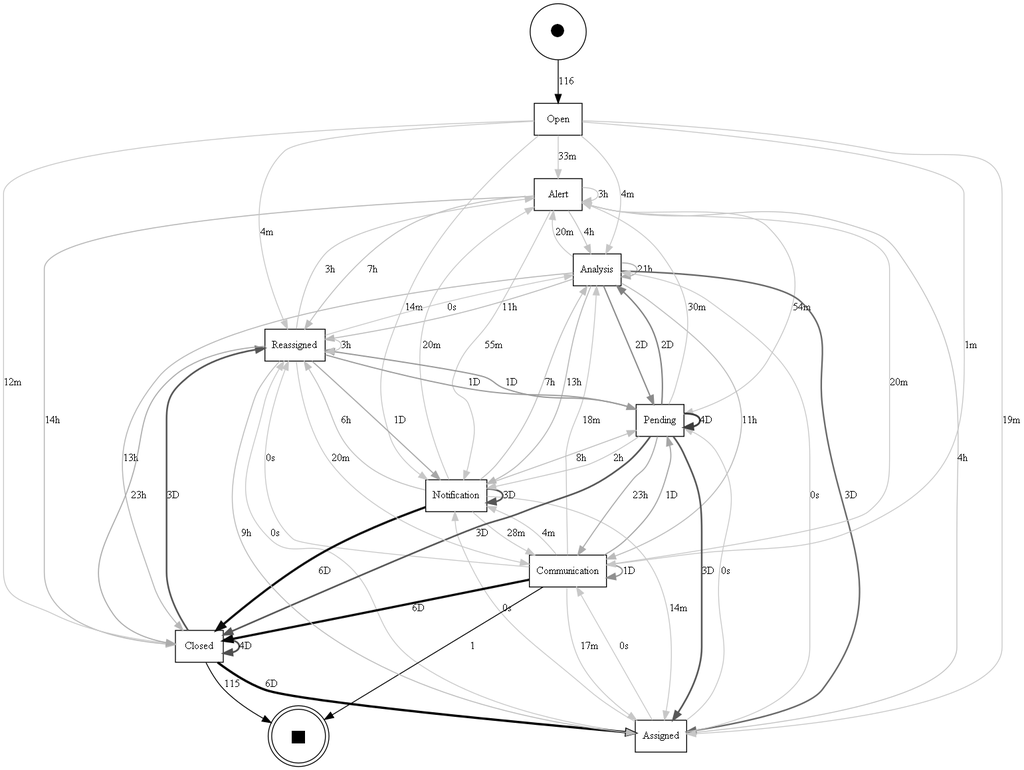

```python
# Apply Direcly follows graph with performance
performance_dfg, start_activities, end_activities = pm4py.discover_performance_dfg(log)
pm4py.view_performance_dfg(performance_dfg, start_activities, end_activities)
pm4py.save_vis_performance_dfg(performance_dfg, start_activities, end_activities, 'perf_dfg.svg')
```

A temporal profile measures for every couple of activities in the log the average time and the standard deviation between events having the provided activities. The time is measured between the completion of the first event and the start of the second event. Hence, it is assumed to work with an interval log where the events have two timestamps. The output of the temporal profile discovery is a dictionary where each couple of activities (expressed as a tuple) is associated to a couple of numbers, the first is the average and the second is the average standard deviation.

```python
# Calculating profile measures for every couple of activities
from pm4py.algo.discovery.temporal_profile import algorithm as temporal_profile_discovery
temporal_profile = temporal_profile_discovery.apply(log)
temporal_profile
```

```
{('Open', 'Notification'): (110714.14285714286, 685992.0009412465),
 ('Open', 'Assigned'): (273772.7272727273, 1117469.641946974),
 ('Open', 'Analysis'): (178280.0, 705777.7372360807),
 ('Open', 'Pending'): (829077.3626373627, 1569444.3085095333),
 ('Open', 'Reassigned'): (334323.26086956525, 1148339.4671897911),
 ('Open', 'Closed'): (599480.3921568628, 1014947.8630334472),
 ('Notification', 'Assigned'): (495356.96202531643, 1582253.1493333385),
 ('Notification', 'Analysis'): (194259.88439306358, 816593.4220027284),
 ('Notification', 'Pending'): (870339.1304347826, 1717761.4261169615),
 ('Notification', 'Reassigned'): (441351.9587628866, 1427299.2427823835),
 ('Notification', 'Notification'): (517485.71428571426, 1552627.4455605936),
 ('Notification', 'Closed'): (631170.6593406594, 1076671.4053657039),
 ('Assigned', 'Analysis'): (307639.0243902439, 1133407.5743262102),
 ('Assigned', 'Assigned'): (1183361.8604651163, 2425337.71771043),
 ('Assigned', 'Pending'): (1046304.6153846154, 1963623.1628739426),
 ('Assigned', 'Reassigned'): (465240.50420168065, 1543071.3456565072),
 ('Assigned', 'Notification'): (341316.0, 1403231.89827838),
 ('Assigned', 'Closed'): (767393.1297709923, 1336241.9300313755),
 ('Analysis', 'Assigned'): (844638.6206896552, 1913384.953752691),
 ('Analysis', 'Pending'): (996338.6666666666, 1677445.555930696),
 ('Analysis', 'Reassigned'): (544954.9450549451, 1563751.493481389),
 ('Analysis', 'Notification'): (719617.2413793104, 1960397.6855855705),
 ('Analysis', 'Analysis'): (384156.70588235295, 1187846.1746044194),
 ('Analysis', 'Closed'): (668393.804347826, 1155928.0316899708),
 ('Pending', 'Assigned'): (1407000.0, 2593553.191999989),
 ('Pending', 'Reassigned'): (1085733.8461538462, 2238919.986841183),
 ('Pending', 'Notification'): (1014369.4736842106, 2350792.8571665483),
 ('Pending', 'Analysis'): (787336.0, 1575828.4524228692),
 ('Pending', 'Closed'): (1037562.5, 1471564.6858704693),
 ('Reassigned', 'Reassigned'): (496401.29032258067, 1652811.6148675054),
 ('Reassigned', 'Notification'): (295277.77777777775, 1288309.0825657418),
 ('Reassigned', 'Assigned'): (803465.0, 2132510.9914377597),
 ('Reassigned', 'Analysis'): (369367.5, 1373039.8112008818),
 ('Reassigned', 'Closed'): (605572.8571428572, 1131017.4928117476),
 ('Open', 'Alert'): (250039.37007874015, 1194764.444252671),
 ('Assigned', 'Alert'): (1433762.448979592, 2720482.619746702),
 ('Analysis', 'Alert'): (2480937.3913043477, 3164182.6418512706),
 ('Alert', 'Alert'): (622755.671641791, 1913646.3339537974),
 ('Alert', 'Notification'): (246854.78260869565, 1140472.7005179015),
 ('Alert', 'Assigned'): (569631.8644067796, 1678778.2857398733),
```

[output cut: 16 more lines]

```
 ('Pending', 'Communication'): (467616.77419354836, 472507.04900835146),
 ('Communication', 'Pending'): (1141992.857142857, 1121764.4556213005),
 ('Communication', 'Closed'): (1787116.8, 1546183.794785083),
 ('Closed', 'Assigned'): (425400.0, 146741.11080402794),
 ('Closed', 'Reassigned'): (391780.0, 103392.83611546789),
 ('Closed', 'Pending'): (880185.0, 859298.0130897546),
 ('Communication', 'Communication'): (536622.0, 552972.437259106),
 ('Communication', 'Notification'): (80460.0, 106124.04063170607),
 ('Communication', 'Reassigned'): (207832.0, 221732.07716907872),
 ('Communication', 'Alert'): (3645.0, 2583.6601943754135),
 ('Communication', 'Assigned'): (8172.0, 8530.599041099049),
 ('Communication', 'Analysis'): (494021.53846153844, 608242.5296136149),
 ('Closed', 'Alert'): (339630.0, 1296.6109670984586),
 ('Closed', 'Notification'): (340320.0, 1442.497833620557),
 ('Closed', 'Analysis'): (362820.0, 38354.363506646805)}
```

```python
# To export a petrinet file
pm4py.write_pnml(net, initial_marking, final_marking, "petri.pnml")
```

### Process Trees

```python
# Create a tree and visualize it
process_tree = pm4py.discover_process_tree_inductive(log)
pm4py.view_process_tree(process_tree, format='png')
```

[output not shown]

```python
# To export process tree
pm4py.write_ptml(process_tree, "process_tree.ptml")
```

```python
# A log can be matched against a process tree in an optimal way using the alignments algorithm.
# The results of the alignments algorithm contains the list of leaves/operators visited during the replay.
# This can be used to infer the frequency at the case/event level of every node of the process tree.
from pm4py.algo.conformance.alignments.process_tree.util import search_graph_pt_frequency_annotation
aligned_traces = pm4py.conformance_diagnostics_alignments(log, tree)
tree = search_graph_pt_frequency_annotation.apply(tree, aligned_traces)
```

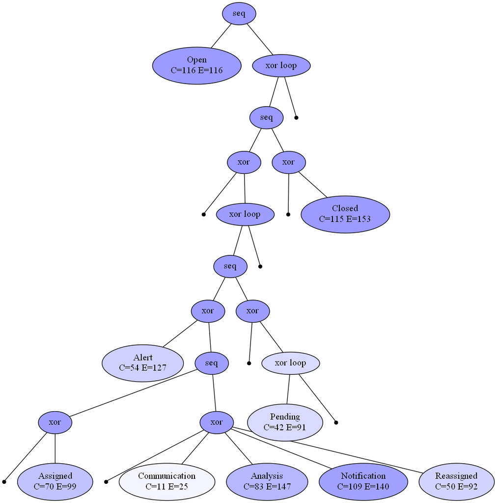

```python
# To display
from pm4py.visualization.process_tree import visualizer as pt_visualizer
gviz = pt_visualizer.apply(tree, parameters={"format": "png"}, variant=pt_visualizer.Variants.FREQUENCY_ANNOTATION)
pt_visualizer.view(gviz)
```

### Feature selection

An operation of feature selection permits to represent the event log in a tabular way. This is important for operations such as prediction and anomaly detection

Printing the value feature_names, we see that the following attributes were selected:

```python
# For performing feature selection
from pm4py.algo.transformation.log_to_features import algorithm as log_to_features
data, feature_names = log_to_features.apply(log)
print(feature_names)
```

```
['event:concept:name@Alert', 'event:concept:name@Analysis', 'event:concept:name@Assigned', 'event:concept:name@Closed', 'event:concept:name@Communication', 'event:concept:name@Notification', 'event:concept:name@Open', 'event:concept:name@Pending', 'event:concept:name@Reassigned', 'trace:@@index', 'e…
```

```python
# To convert in a datafrane for applying ML models
df = pd.DataFrame(data, columns=feature_names)
print(df)
```

```
     event:concept:name@Alert  event:concept:name@Analysis  \
0                           0                            1
1                           0                            1
2                           0                            1
3                           1                            1
4                           1                            1
..                        ...                          ...
111                         0                            0
112                         0                            1
113                         1                            1
114                         1                            1
115                         1                            1

     event:concept:name@Assigned  event:concept:name@Closed  \
0                              1                          1
```

[output cut: 181 more lines]

```python
# To apply isolation forest
from sklearn.ensemble import IsolationForest
model=IsolationForest()
model.fit(df)
df["scores"] = model.decision_function(df)
```

```python
# To display results
df["scores"]
```

```
0     -0.026685
1      0.130702
2      0.130702
3      0.010265
4      0.065958
         ...
111    0.130973
112    0.134450
113   -0.048266
114    0.102324
115   -0.032234
Name: scores, Length: 116, dtype: float64
```

### Social Network Analysis

Given the results of applying a SNA metric, a clustering operation permits to group the resources that are connected by a meaningful connection in the given metric. For example:

- Clustering the results of the working together metric, individuals that work often together would be inserted in the same group.
- Clustering the results of the similar activities metric, individuals that work on the same tasks would be inserted in the same group.

```python
# Applying clustering
sa_metric = pm4py.discover_activity_based_resource_similarity(log)
from pm4py.algo.organizational_mining.sna import util
clustering = util.cluster_affinity_propagation(sa_metric)
```

```python
# Displaying results
clustering
```

```
{'4': ['RES01',
  'RES1011',
  'RES1071',
  'RES1091',
  'RES111',
  'RES1111',
  'RES1181',
  'RES1191',
  'RES1211',
  'RES1231',
  'RES1251',
  'RES1281',
  'RES1301',
  'RES131',
  'RES1311',
  'RES191',
  'RES211',
  'RES241',
  'RES281',
  'RES311',
  'RES331',
  'RES351',
  'RES381',
  'RES401',
  'RES41',
  'RES421',
  'RES461',
  'RES481',
  'RES491',
  'RES511',
  'RES541',
  'RES551',
  'RES571',
  'RES591',
  'RES61',
  'RES681',
  'RES691',
  'RES741',
  'RES751',
  'RES761',
```

[output cut: 79 more lines]

```
  'RES451',
  'RES81',
  'RES831',
  'RES981'],
 '0': ['RES1141', 'RES1331', 'RES651'],
 '1': ['RES1151',
  'RES1171',
  'RES1371',
  'RES201',
  'RES501',
  'RES661',
  'RES731',
  'RES841',
  'RES901'],
 '7': ['RES531', 'RES601', 'RES771']}
```

Basically, the behavior of a resource can be measured over a period of time with different metrics:

- RBI 1.1 (number of distinct activities): Number of distinct activities done by a resource in a given time interval [t1, t2)
- RBI 1.3 (activity frequency): Fraction of completions of a given activity a, by a given resource r, during a given time slot, - [t1, t2), with respect to the total number of activity completions by resource r during [t1, t2)
- RBI 2.1 (activity completions): The number of activity instances completed by a given resource during a given time slot.
- RBI 2.2 (case completions): The number of cases completed during a given time slot in which a given resource was involved.
- RBI 2.3 (fraction case completion): The fraction of cases completed during a given time slot in which a given resource was involved with respect to the total number of cases completed during the time slot.
- RBI 2.4 (average workload): The average number of activities started by a given resource but not completed at a moment in time
- RBI 3.1 (multitasking): The fraction of active time during which a given resource is involved in more than one activity with respect to the resource's active time
- RBI 4.3 (average duration activity): The average duration of instances of a given activity completed during a given time slot by a given resource
- RBI 4.4 (average case duration): The average duration of cases completed during a given time slot in which a given resource was involved
- RBI 5.1 (interaction two resources): The number of cases completed during a given time slot in which two given resources were involved
- RBI 5.2 (social position): The fraction of resources involved in the same cases with a given resource during a given time slot with respect to the total number of resources active during the time slot

```python
#from pm4py.algo.organizational_mining.resource_profiles import algorithm
#print(algorithm.distinct_activities(log, "2010-01-01 18:00:00", "2011-01-01 08:26:00", "RES2771"))
```

With event logs, we are able to identify groups of resources doing similar activities. As we have seen in the previous sections, we have different ways to detect automatically these groups from event logs:

Discovering the Similar Activities metric and applying a clustering algorithm to find the groups. Applying the roles discovery algorithm (Burattin et al.) As a third option, an attribute might be there in the events, describing the group that performed the event.

With the term organizational mining, we mean the discovery of behavior-related information specific to an organizational group (e.g. which activities are done by the group?)

The approach provides the description of some group-related metrics (local diagnostics). Among these, we have:

- Group Relative Focus: (on a given type of work) specifies how much a resource group performed this type of work compared to the overall workload of the group. It can be used to measure how the workload of a resource group is distributed over different types of work, i.e., work diversification of the group
- Group Relative Stake: (in a given type of work) specifies how much this type of work was performed by a certain resource group among all groups. It can be used to measure how the workload devoted to a certain type of work is distributed over resource groups in an organizational model, i.e., work participation by different groups
- Group Coverage: with respect to a given type of work specifies the proportion of members of a resource group that performed this type of work
- Group Member Contribution: of a member of a resource group with respect to the given type of work specifies how much of this type of work by the group was performed by the member. It can be used to measure how the workload of the entire group devoted to a certain type of work is distributed over the group members

```python
from pm4py.algo.organizational_mining.local_diagnostics import algorithm as local_diagnostics
ld = local_diagnostics.apply_from_group_attribute(log, parameters={local_diagnostics.Parameters.GROUP_KEY: "org:resource"})

# Following metric specifies how much a resource performed one type of work compared to the overall workload of the group.
# It can be used to measure how the workload of a resource i.e., work diversification of the group.
print("\ngroup_relative_focus")
print(ld["group_relative_focus"])
```

```
group_relative_focus
{'RES01': {'Open': 0.008620689655172414, 'Notification': 0.0, 'Assigned': 0.0, 'Analysis': 0.0, 'Pending': 0.0, 'Reassigned': 0.0, 'Closed': 0.0, 'Alert': 0.0, 'Communication': 0.0}, 'RES11': {'Open': 0.0, 'Notification': 0.06428571428571428, 'Assigned': 0.030303030303030304, 'Analysis': 0.054421768…
```

```python
# Specifies how much this type of work was performed by a certain resource among all groups.
# It can be used to measure how the workload devoted to a certain type of work is distributed over resource groups in an organizational model
# i.e., work participation by different groups
print("\ngroup_relative_stake")
print(ld["group_relative_stake"])
```

```
group_relative_stake
{'RES01': {'Open': 1.0, 'Notification': 0.0, 'Assigned': 0.0, 'Analysis': 0.0, 'Pending': 0.0, 'Reassigned': 0.0, 'Closed': 0.0, 'Alert': 0.0, 'Communication': 0.0}, 'RES11': {'Open': 0.0, 'Notification': 0.3103448275862069, 'Assigned': 0.10344827586206896, 'Analysis': 0.27586206896551724, 'Pending'…
```

```python
# specifies the proportion of members of a resource group that performed this type of work.
print("\ngroup_coverage")
print(ld["group_coverage"])
```

```
group_coverage
{'RES01': {'RES01': 1.0}, 'RES11': {'RES11': 1.0}, 'RES21': {'RES21': 1.0}, 'RES31': {'RES31': 1.0}, 'RES41': {'RES41': 1.0}, 'RES51': {'RES51': 1.0}, 'RES61': {'RES61': 1.0}, 'RES71': {'RES71': 1.0}, 'RES81': {'RES81': 1.0}, 'RES91': {'RES91': 1.0}, 'RES101': {'RES101': 1.0}, 'RES111': {'RES111': 1…
```

```python
# Specifies how much of this type of work by the group was performed by the member.
# It can be used to measure how the workload of the entire group devoted to a certain type of work is distributed over the group members
print("\ngroup_member_contribution")
print(ld["group_member_contribution"])
```

```
group_member_contribution
{'RES01': {'RES01': {'Open': 1}}, 'RES11': {'RES11': {'Notification': 9, 'Assigned': 3, 'Analysis': 8, 'Alert': 4, 'Reassigned': 2, 'Closed': 3}}, 'RES21': {'RES21': {'Assigned': 3, 'Analysis': 3, 'Reassigned': 3, 'Closed': 3}}, 'RES31': {'RES31': {'Assigned': 4, 'Pending': 1, 'Reassigned': 5, 'Noti…
```